# Wine Quality Predictor

# INTRODUCTION

**Team Member :** Shradhit Subudhi  
**Professor’s Name :** Dr. Douglas Jones  
**Course Period :** Fall - 2018 (September - December)  
**Date :** “December 3, 2018”

## Inspiration for Project

**“In wine, there’s truth”** - Pliny the Elder.

## Question

**Can we predict the quality of wine using data analysis techniques?**

# Wine Data Set - Info

The two datasets are related to red and white variants of the Portuguese *“Vinho Verde”* wine. Due to privacy and logistic issues, only physicochemical (inputs) and sensory (the output) variables are available (e.g. there is no data about grape types, wine brand, wine selling price, etc.).

These datasets can be viewed as classification or regression tasks. The classes are ordered and not balanced (e.g. there are much more normal wines than excellent or poor ones). Outlier detection algorithms could be used to detect the few excellent or poor wines. Also, we are not sure if all input variables are relevant. So it could be interesting to test feature selection methods.

> We worked on predicting the **white wine quality** for this project. Worst wine is represented with 0 and the best wine is represented as 10.

# Packages Installed

```r
library("rmdformats")


library("corrgram")

library("MASS")
library("ggplot2")
library("naniar")
library("e1071")
library("lattice")
library("caret")
library("car")
library("caTools")
library("corrplot")
library("knitr")
```

# Inputting Data

Importing the data with the help of a url and assigning it to white.

```r
white_url <- "https://archive.ics.uci.edu/ml/machine-learning-databases/wine-quality/winequality-white.csv"
whitewine <- read.csv(white_url, header = TRUE, sep = ";")
white <- whitewine
```

# Data - First View

Viewing the loaded data.

```r
str(white)
```

```
## 'data.frame':    4898 obs. of  12 variables:
##  $ fixed.acidity       : num  7 6.3 8.1 7.2 7.2 8.1 6.2 7 6.3 8.1 ...
##  $ volatile.acidity    : num  0.27 0.3 0.28 0.23 0.23 0.28 0.32 0.27 0.3 0.22 ...
##  $ citric.acid         : num  0.36 0.34 0.4 0.32 0.32 0.4 0.16 0.36 0.34 0.43 ...
##  $ residual.sugar      : num  20.7 1.6 6.9 8.5 8.5 6.9 7 20.7 1.6 1.5 ...
##  $ chlorides           : num  0.045 0.049 0.05 0.058 0.058 0.05 0.045 0.045 0.049 0.044 ...
##  $ free.sulfur.dioxide : num  45 14 30 47 47 30 30 45 14 28 ...
##  $ total.sulfur.dioxide: num  170 132 97 186 186 97 136 170 132 129 ...
##  $ density             : num  1.001 0.994 0.995 0.996 0.996 ...
##  $ pH                  : num  3 3.3 3.26 3.19 3.19 3.26 3.18 3 3.3 3.22 ...
##  $ sulphates           : num  0.45 0.49 0.44 0.4 0.4 0.44 0.47 0.45 0.49 0.45 ...
##  $ alcohol             : num  8.8 9.5 10.1 9.9 9.9 10.1 9.6 8.8 9.5 11 ...
##  $ quality             : int  6 6 6 6 6 6 6 6 6 6 ...
```

Looking at the output we get to know that we have 4898 samples and 12 variables.  
The response variable is *quality.*  
The *eleven predictor variables* are of the *numeric class* and the *response variable*, quality, is of the *integer class.*

We don’t see any categorical variable in the dataset.

## Columns

We then check the names of the variables present in the data.

```r
colnames(white)
```

```
##  [1] "fixed.acidity"        "volatile.acidity"     "citric.acid"
##  [4] "residual.sugar"       "chlorides"            "free.sulfur.dioxide"
##  [7] "total.sulfur.dioxide" "density"              "pH"
## [10] "sulphates"            "alcohol"              "quality"
```

Look at the summary to better understand the dataset.

```r
summary(white)
```

```
##  fixed.acidity    volatile.acidity  citric.acid     residual.sugar
##  Min.   : 3.800   Min.   :0.0800   Min.   :0.0000   Min.   : 0.600
##  1st Qu.: 6.300   1st Qu.:0.2100   1st Qu.:0.2700   1st Qu.: 1.700
##  Median : 6.800   Median :0.2600   Median :0.3200   Median : 5.200
##  Mean   : 6.855   Mean   :0.2782   Mean   :0.3342   Mean   : 6.391
##  3rd Qu.: 7.300   3rd Qu.:0.3200   3rd Qu.:0.3900   3rd Qu.: 9.900
##  Max.   :14.200   Max.   :1.1000   Max.   :1.6600   Max.   :65.800
##    chlorides       free.sulfur.dioxide total.sulfur.dioxide
##  Min.   :0.00900   Min.   :  2.00      Min.   :  9.0
##  1st Qu.:0.03600   1st Qu.: 23.00      1st Qu.:108.0
##  Median :0.04300   Median : 34.00      Median :134.0
##  Mean   :0.04577   Mean   : 35.31      Mean   :138.4
##  3rd Qu.:0.05000   3rd Qu.: 46.00      3rd Qu.:167.0
##  Max.   :0.34600   Max.   :289.00      Max.   :440.0
##     density             pH          sulphates         alcohol
##  Min.   :0.9871   Min.   :2.720   Min.   :0.2200   Min.   : 8.00
##  1st Qu.:0.9917   1st Qu.:3.090   1st Qu.:0.4100   1st Qu.: 9.50
##  Median :0.9937   Median :3.180   Median :0.4700   Median :10.40
##  Mean   :0.9940   Mean   :3.188   Mean   :0.4898   Mean   :10.51
##  3rd Qu.:0.9961   3rd Qu.:3.280   3rd Qu.:0.5500   3rd Qu.:11.40
##  Max.   :1.0390   Max.   :3.820   Max.   :1.0800   Max.   :14.20
##     quality
##  Min.   :3.000
##  1st Qu.:5.000
##  Median :6.000
##  Mean   :5.878
##  3rd Qu.:6.000
##  Max.   :9.000
```

## Removing the Duplicate Rows

```r
#white <-  unique(white)
white <- white[!duplicated(white), ]
dim(white)
```

```
## [1] 3961   12
```

The rows got reduced to 3961 after removing the duplicates.

## Checking for NA

### Graphically

Checking if there are any missing (NA) values.

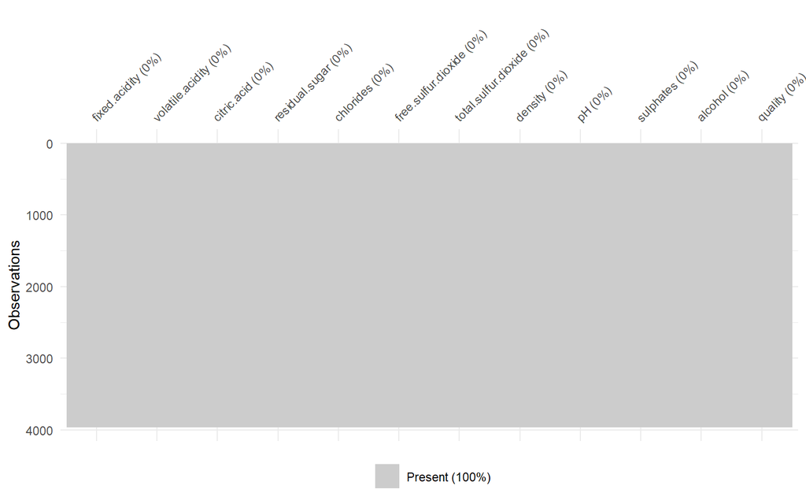

```r
vis_miss(white)
```

100% values of all columns are present.

### Technically

```r
sum(is.na(white))
```

```
## [1] 0
```

There is no NA values in the data set.

## Response Count

```r
table(white$quality)
```

```
##
##    3    4    5    6    7    8    9
##   20  153 1175 1788  689  131    5
```

We can see that the class is skewed i.e. it has imbalance.  
There are 3961 samples but only 20 points are from 3rd class and only 5 points are from the 9th class.  
Wines with lowest and highest quality are rare. Generally, wines have quality 5 and 6 which is in the medium range(not low, not high).

```r
#rounds the values in its first argument to the specified number of decimal places (default 0).

round(cor(white, method = "pearson"), 2)
```

```
##                      fixed.acidity volatile.acidity citric.acid
## fixed.acidity                 1.00            -0.02        0.30
## volatile.acidity             -0.02             1.00       -0.16
## citric.acid                   0.30            -0.16        1.00
## residual.sugar                0.08             0.10        0.11
## chlorides                     0.02             0.09        0.13
## free.sulfur.dioxide          -0.06            -0.10        0.09
## total.sulfur.dioxide          0.08             0.10        0.12
## density                       0.27             0.06        0.16
## pH                           -0.43            -0.05       -0.18
## sulphates                    -0.02            -0.02        0.05
## alcohol                      -0.11             0.05       -0.08
## quality                      -0.12            -0.19        0.01
##                      residual.sugar chlorides free.sulfur.dioxide
## fixed.acidity                  0.08      0.02               -0.06
## volatile.acidity               0.10      0.09               -0.10
## citric.acid                    0.11      0.13                0.09
## residual.sugar                 1.00      0.08                0.31
## chlorides                      0.08      1.00                0.10
## free.sulfur.dioxide            0.31      0.10                1.00
## total.sulfur.dioxide           0.41      0.19                0.62
## density                        0.82      0.25                0.29
## pH                            -0.17     -0.09               -0.01
## sulphates                     -0.02      0.02                0.04
## alcohol                       -0.40     -0.36               -0.25
## quality                       -0.12     -0.22                0.01
##                      total.sulfur.dioxide density    pH sulphates alcohol
## fixed.acidity                        0.08    0.27 -0.43     -0.02   -0.11
## volatile.acidity                     0.10    0.06 -0.05     -0.02    0.05
## citric.acid                          0.12    0.16 -0.18      0.05   -0.08
## residual.sugar                       0.41    0.82 -0.17     -0.02   -0.40
## chlorides                            0.19    0.25 -0.09      0.02   -0.36
## free.sulfur.dioxide                  0.62    0.29 -0.01      0.04   -0.25
## total.sulfur.dioxide                 1.00    0.54  0.01      0.14   -0.45
## density                              0.54    1.00 -0.06      0.08   -0.76
## pH                                   0.01   -0.06  1.00      0.14    0.09
## sulphates                            0.14    0.08  0.14      1.00   -0.02
## alcohol                             -0.45   -0.76  0.09     -0.02    1.00
## quality                             -0.18   -0.34  0.12      0.05    0.46
##                      quality
## fixed.acidity          -0.12
## volatile.acidity       -0.19
## citric.acid             0.01
## residual.sugar         -0.12
## chlorides              -0.22
## free.sulfur.dioxide     0.01
## total.sulfur.dioxide   -0.18
## density                -0.34
## pH                      0.12
## sulphates               0.05
## alcohol                 0.46
## quality                 1.00
```

## Correlation Matrix

We now check the correlation matrix, confidence interval with the help of corrplot package.It also helps us to do matrix reordering.

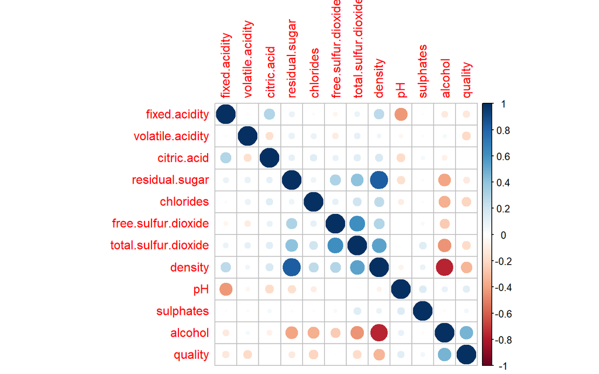

```r
corrplot(cor(white))
```

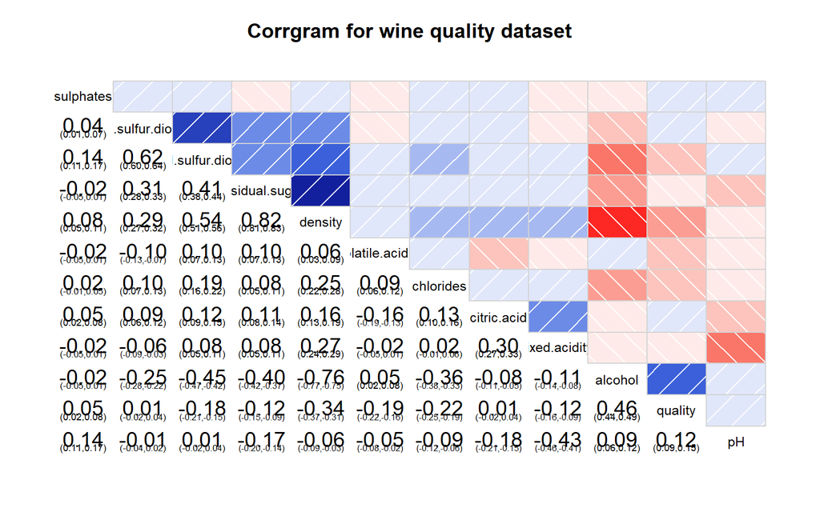

```r
corrgram(white, type="data", lower.panel=panel.conf,
         upper.panel=panel.shade, main= "Corrgram for wine quality dataset", order=T, cex.labels=1.2)
```

Sugar,pH and citric acid factors are not playing a really big role in the quality of wine.

alcohol is kind of strongly correlated to the quality of wine.

## Histogram

Plotting the histograms using hist() for the data.

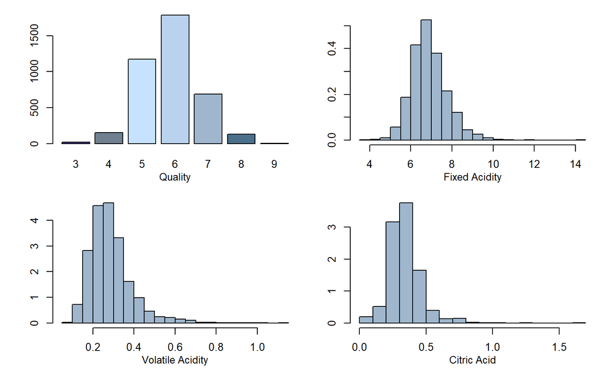

```r
attach(white)

par(mfrow=c(2,2), oma = c(1,1,0,0) + 0.1, mar = c(3,3,1,1) + 0.1)
barplot((table(quality)), col=c("slateblue4", "slategray", "slategray1", "slategray2", "slategray3", "skyblue4"))
mtext("Quality", side=1, outer=F, line=2, cex=0.8)


truehist(fixed.acidity, h = 0.5, col="slategray3")
mtext("Fixed Acidity", side=1, outer=F, line=2, cex=0.8)

truehist(volatile.acidity, h = 0.05, col="slategray3")
mtext("Volatile Acidity", side=1, outer=F, line=2, cex=0.8)

truehist(citric.acid, h = 0.1, col="slategray3")
mtext("Citric Acid", side=1, outer=F, line=2, cex=0.8)
```

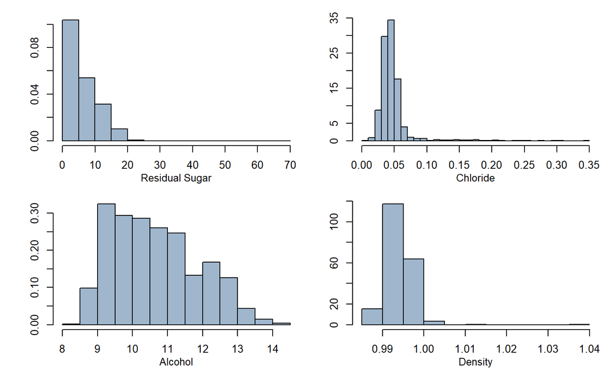

```r
par(mfrow=c(2,2), oma = c(1,1,0,0) + 0.1, mar = c(3,3,1,1) + 0.1)




truehist(residual.sugar, h = 5, col="slategray3")
mtext("Residual Sugar", side=1, outer=F, line=2, cex=0.8)

truehist(chlorides, h = 0.01, col="slategray3")
mtext("Chloride", side=1, outer=F, line=2, cex=0.8)

truehist(alcohol, h = 0.5, col="slategray3")
mtext("Alcohol", side=1, outer=F, line=2, cex=0.8)


truehist(density, h = 0.005, col="slategray3")
mtext("Density", side=1, outer=F, line=2, cex=0.8)
```

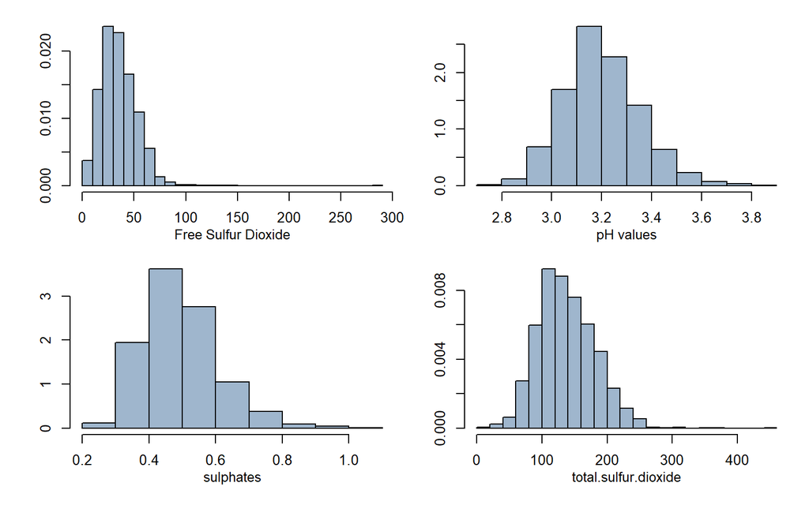

```r
par(mfrow=c(2,2), oma = c(1,1,0,0) + 0.1, mar = c(3,3,1,1) + 0.1)

 truehist(free.sulfur.dioxide, h = 10, col="slategray3")
mtext("Free Sulfur Dioxide", side=1, outer=F, line=2, cex=0.8)

truehist(pH, h = 0.1, col="slategray3")
mtext("pH values", side=1, outer=F, line=2, cex=0.8)

truehist(sulphates, h = 0.1, col="slategray3")
mtext("sulphates", side=1, outer=F, line=2, cex=0.8)


truehist(total.sulfur.dioxide, h = 20, col="slategray3")
mtext("total.sulfur.dioxide", side=1, outer=F, line=2, cex=0.8)
```

## Boxplot

Y ^(lambda) where Y would be the values in the dataset and lambda would be the exponent (ranges from -5 to 5).

Examples  
If lambda = 2, all the values would be squared.  
If lambda = 0.5, the square root of the values would be taken.  
If lambda = 0, the log of the values would be taken.

Plotting the boxplots using boxplot() for the data.

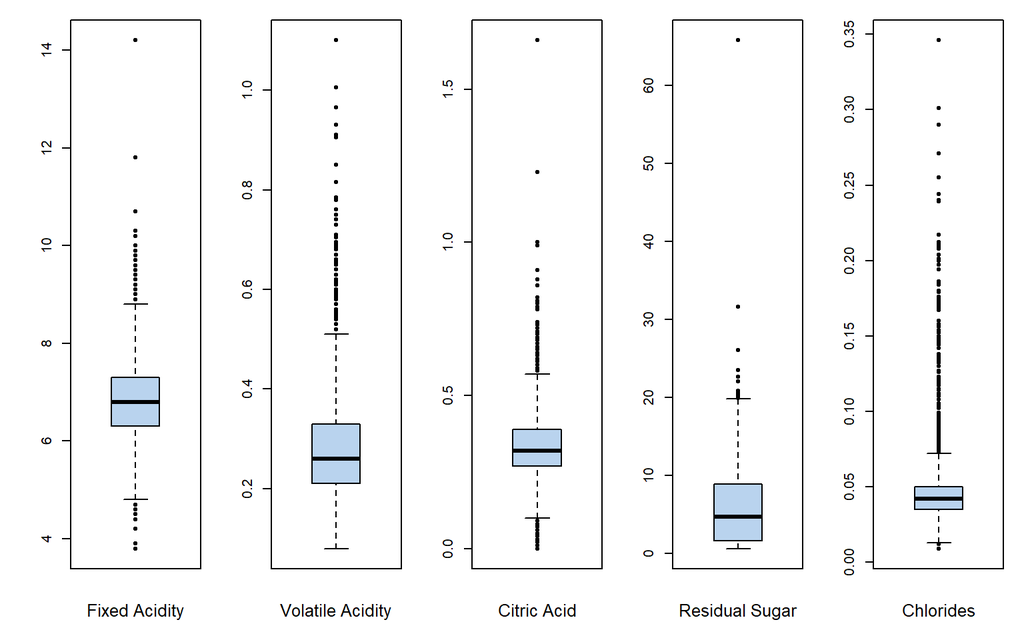

```r
par(mfrow=c(1,5), oma = c(1,1,0,0) + 0.1,  mar = c(3,3,1,1) + 0.1)

boxplot(fixed.acidity, col="slategray2", pch=19)
mtext("Fixed Acidity", cex=0.8, side=1, line=2)

boxplot(volatile.acidity, col="slategray2", pch=19)
mtext("Volatile Acidity", cex=0.8, side=1, line=2)

boxplot(citric.acid, col="slategray2", pch=19)
mtext("Citric Acid", cex=0.8, side=1, line=2)

boxplot(residual.sugar, col="slategray2", pch=19)
mtext("Residual Sugar", cex=0.8, side=1, line=2)

boxplot(chlorides, col="slategray2", pch=19)
mtext("Chlorides", cex=0.8, side=1, line=2)
```

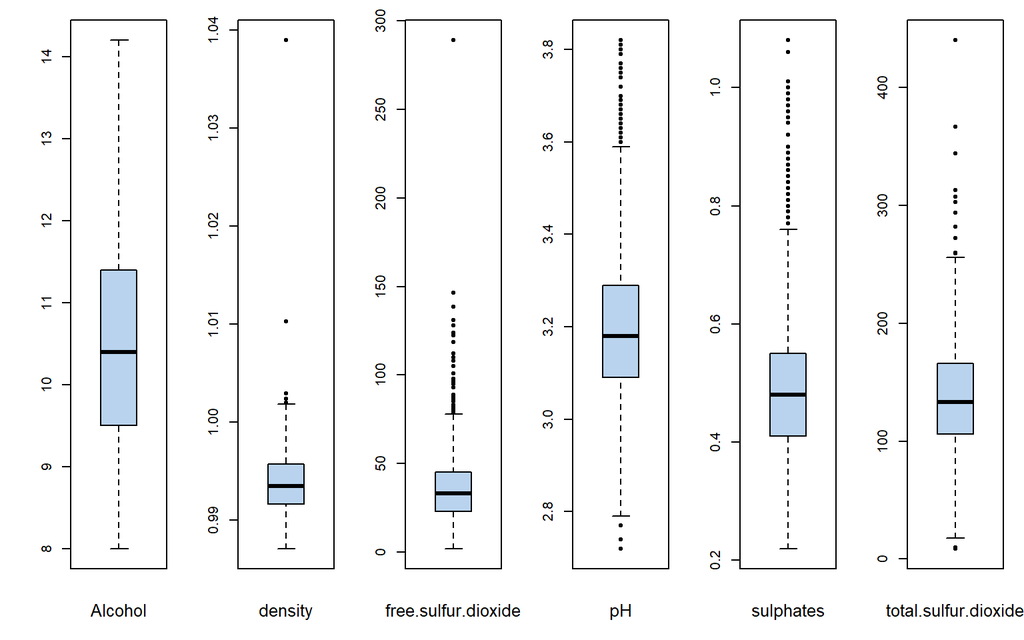

```r
par(mfrow=c(1,6), oma = c(1,1,0,0) + 0.1,  mar = c(3,3,1,1) + 0.1)

boxplot(alcohol, col="slategray2", pch=19)
mtext("Alcohol", cex=0.8, side=1, line=2)

boxplot(density, col="slategray2", pch=19)
mtext("density", cex=0.8, side=1, line=2)

boxplot(free.sulfur.dioxide, col="slategray2", pch=19)
mtext("free.sulfur.dioxide", cex=0.8, side=1, line=2)

boxplot( pH, col="slategray2", pch=19)
mtext("pH", cex=0.8, side=1, line=2)

boxplot(sulphates, col="slategray2", pch=19)
mtext("sulphates", cex=0.8, side=1, line=2)




boxplot(total.sulfur.dioxide, col="slategray2", pch=19)
mtext("total.sulfur.dioxide", cex=0.8, side=1, line=2)
```

```r
detach(white)
```

## Skewness

Checking the skewness of the individual variables of the data to check whether the data is normally distributed or not.

```r
attach(white)

skewness(quality)
```

```
## [1] 0.1119192
```

```r
skewness(chlorides)
```

```
## [1] 4.965313
```

```r
skewness(free.sulfur.dioxide)
```

```
## [1] 1.565494
```

```r
skewness(residual.sugar)
```

```
## [1] 1.332629
```

```r
skewness(alcohol)
```

```
## [1] 0.4503553
```

```r
skewness(citric.acid)
```

```
## [1] 1.309609
```

```r
skewness(density)
```

```
## [1] 1.272354
```

```r
skewness(fixed.acidity)
```

```
## [1] 0.6955731
```

```r
skewness(volatile.acidity)
```

```
## [1] 1.639838
```

```r
skewness(total.sulfur.dioxide)
```

```
## [1] 0.4564538
```

```r
skewness(sulphates)
```

```
## [1] 0.9371431
```

```r
skewness(pH)
```

```
## [1] 0.4551119
```

```r
colnames(white)
```

```
##  [1] "fixed.acidity"        "volatile.acidity"     "citric.acid"
##  [4] "residual.sugar"       "chlorides"            "free.sulfur.dioxide"
##  [7] "total.sulfur.dioxide" "density"              "pH"
## [10] "sulphates"            "alcohol"              "quality"
```

```r
detach(white)
```

## Skewness Rule of Thumb

**If skewness is 0, the data are perfectly symmetrical.**  
**As a general rule of thumb: If skewness is less than -1 or greater than 1, the distribution is highly skewed.**  
**If skewness is between -0.5 and 0.5, the distribution is approximately symmetric.**

# Data Transformation / Preparation

## Box Cox Transformation

We use the Boxcox transformation and transform the data and then again check the skewness.

```r
preprocess_white <- preProcess(white[,1:11], c("BoxCox", "center", "scale"))
new_white <- data.frame(trans = predict(preprocess_white, white))

colnames(new_white)
```

```
##  [1] "trans.fixed.acidity"        "trans.volatile.acidity"
##  [3] "trans.citric.acid"          "trans.residual.sugar"
##  [5] "trans.chlorides"            "trans.free.sulfur.dioxide"
##  [7] "trans.total.sulfur.dioxide" "trans.density"
##  [9] "trans.pH"                   "trans.sulphates"
## [11] "trans.alcohol"              "trans.quality"
```

### Skewness - Transformed Data

```r
skewness(new_white$trans.quality)
```

```
## [1] 0.1119192
```

```r
skewness(new_white$trans.chlorides)
```

```
## [1] -0.1496158
```

```r
skewness(new_white$trans.free.sulfur.dioxide)
```

```
## [1] 0.0950346
```

```r
skewness(new_white$trans.residual.sugar)
```

```
## [1] -0.05826498
```

```r
skewness(new_white$trans.alcohol)
```

```
## [1] 0.03929004
```

```r
skewness(new_white$trans.citric.acid)
```

```
## [1] 1.309609
```

```r
skewness(new_white$trans.density)
```

```
## [1] 1.099659
```

```r
skewness(new_white$trans.fixed.acidity)
```

```
## [1] 0.1131388
```

```r
skewness(new_white$trans.volatile.acidity)
```

```
## [1] 0.171864
```

```r
skewness(new_white$trans.total.sulfur.dioxide)
```

```
## [1] 0.008931003
```

```r
skewness(new_white$trans.sulphates)
```

```
## [1] -0.01873289
```

```r
skewness(new_white$trans.pH)
```

```
## [1] 0.0002881265
```

## Removal of Outliers

Most parametric statistics, like means, standard deviations, and correlations, and every statistic based on these, are highly sensitive to outliers.The assumptions of common statistical procedures, like linear regression and ANOVA, are also based on these statistics, outliers can disrupt the analysis. Thus, we remove the outliers.

Possibly, the most important step in data preparation is to identify outliers. Since this is a multivariate data, we consider only those points which do not have any predictor variable value to be outside of limits constructed by boxplots. The following rule is applied:

```r
new_white <- new_white[!abs(new_white$trans.fixed.acidity) > 3,]
new_white <- new_white[!abs(new_white$trans.volatile.acidity) > 3,]
new_white <- new_white[!abs(new_white$trans.citric.acid) > 3,]
new_white <- new_white[!abs(new_white$trans.residual.sugar) > 3,]
new_white <- new_white[!abs(new_white$trans.chlorides) > 3,]
new_white <- new_white[!abs(new_white$trans.density) > 3,]
new_white <- new_white[!abs(new_white$trans.pH) > 3,]
new_white <- new_white[!abs(new_white$trans.sulphates) > 3,]
new_white <- new_white[!abs(new_white$trans.alcohol) > 3,]
```

We now check the correlation matrix, confidence interval with the help of corrplot package.It also helps us to do matrix reordering.

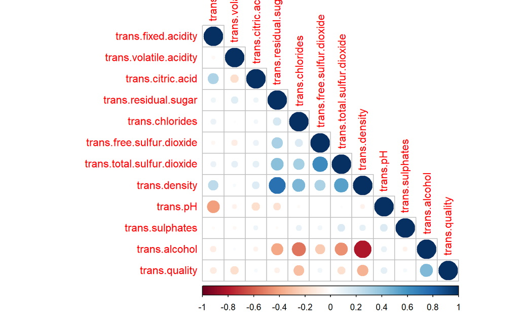

```r
corrplot(cor(new_white), type = "lower")
```

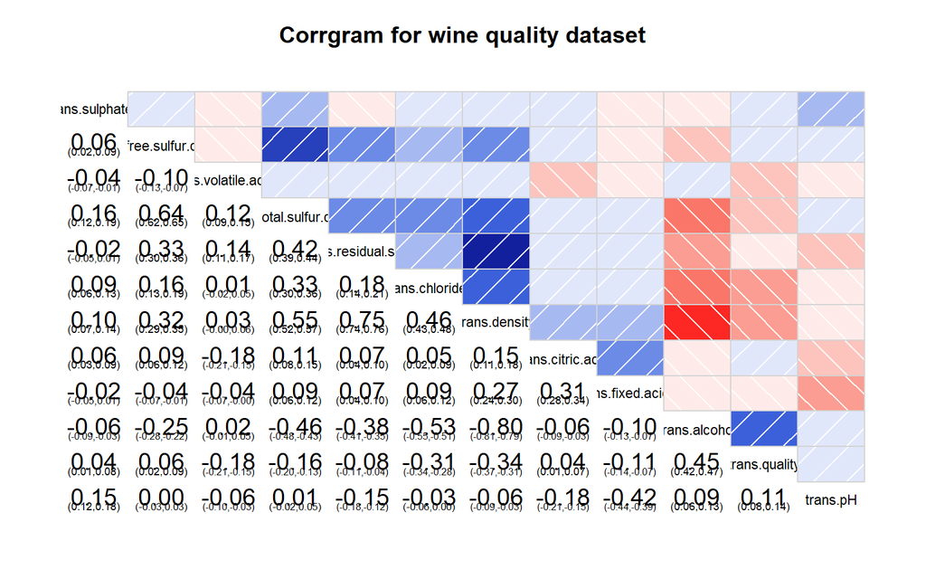

```r
corrgram(new_white, type="data", lower.panel=panel.conf,
         upper.panel=panel.shade, main= "Corrgram for wine quality dataset", order=T, cex.labels=1.1)
```

# Linear Model

## Assumption for linear model

Linear regression is an analysis that assesses whether one or more predictor variables explain the dependent (criterion) variable. The regression has five key assumptions:

Linear relationship  
Multivariate normality  
No or little multicollinearity  
No auto-correlation  
Homoscedasticity

## Train - Test Set

```r
set.seed(100)
trainingRowIndex <- sample(1:nrow(new_white), 0.8*nrow(new_white))
whitetrain <- new_white[trainingRowIndex, ]
whitetest  <- new_white[-trainingRowIndex, ]
```

## Model Selection

Base Model - Trying to choose the best linear model..

```r
linear_0 <- lm(trans.quality ~ . , whitetrain) # taking all the points.
summary(linear_0)
```

```
##
## Call:
## lm(formula = trans.quality ~ ., data = whitetrain)
##
## Residuals:
##     Min      1Q  Median      3Q     Max
## -3.7154 -0.4737 -0.0370  0.4768  3.0699
##
## Coefficients:
##                            Estimate Std. Error t value Pr(>|t|)
## (Intercept)                 5.86221    0.01377 425.612  < 2e-16 ***
## trans.fixed.acidity         0.06476    0.02128   3.044 0.002356 **
## trans.volatile.acidity     -0.16696    0.01530 -10.909  < 2e-16 ***
## trans.citric.acid           0.06819    0.01749   3.898 9.91e-05 ***
## trans.residual.sugar        0.35957    0.03351  10.729  < 2e-16 ***
## trans.chlorides            -0.06810    0.01921  -3.545 0.000398 ***
## trans.free.sulfur.dioxide   0.12545    0.01886   6.652 3.43e-11 ***
## trans.total.sulfur.dioxide -0.05308    0.02141  -2.480 0.013199 *
## trans.density              -0.47660    0.05724  -8.327  < 2e-16 ***
## trans.pH                    0.13383    0.01873   7.144 1.13e-12 ***
## trans.sulphates             0.07597    0.01463   5.192 2.22e-07 ***
## trans.alcohol               0.15887    0.03593   4.422 1.01e-05 ***
## ---
## Signif. codes:  0 '***' 0.001 '**' 0.01 '*' 0.05 '.' 0.1 ' ' 1
##
## Residual standard error: 0.751 on 2988 degrees of freedom
## Multiple R-squared:  0.308,  Adjusted R-squared:  0.3055
## F-statistic: 120.9 on 11 and 2988 DF,  p-value: < 2.2e-16
```

## Checking Multicollinarilty

In multicollinearity,collinearity exists between three or more variables even if no pair of variables has a particularly high correlation. This means that there is redundancy between predictor variables.

In the presence of multicollinearity, the solution of the regression model becomes unstable.

Multicollinearity can assessed by computing a score called the variance inflation factor (or VIF), which measures how much the variance of a regression coefficient is inflated due to multicollinearity in the model.  
The VIF of a predictor is a measure for how easily it is predicted from a linear regression using the other predictors.

```r
# Variance inflation factor

vif(linear_0)
```

```
##        trans.fixed.acidity     trans.volatile.acidity
##                   2.230946                   1.162012
##          trans.citric.acid       trans.residual.sugar
##                   1.172273                   5.903351
##            trans.chlorides  trans.free.sulfur.dioxide
##                   1.452565                   1.898081
## trans.total.sulfur.dioxide              trans.density
##                   2.415348                  16.176165
##                   trans.pH            trans.sulphates
##                   1.710817                   1.124369
##              trans.alcohol
##                   6.687425
```

We can see multicollinarity over here. We remove trans.density cause it exibits multicollinarity.

Now fitting the new model.

```r
linear_1 <- lm(trans.quality ~ . -trans.density , whitetrain)
summary(linear_1)
```

```
##
## Call:
## lm(formula = trans.quality ~ . - trans.density, data = whitetrain)
##
## Residuals:
##     Min      1Q  Median      3Q     Max
## -3.6568 -0.4768 -0.0324  0.4722  3.0679
##
## Coefficients:
##                            Estimate Std. Error t value Pr(>|t|)
## (Intercept)                 5.86572    0.01392 421.278  < 2e-16 ***
## trans.fixed.acidity        -0.04727    0.01667  -2.835 0.004607 **
## trans.volatile.acidity     -0.15950    0.01545 -10.322  < 2e-16 ***
## trans.citric.acid           0.05733    0.01764   3.250 0.001167 **
## trans.residual.sugar        0.11454    0.01622   7.062 2.03e-12 ***
## trans.chlorides            -0.08891    0.01926  -4.616 4.08e-06 ***
## trans.free.sulfur.dioxide   0.13794    0.01901   7.255 5.11e-13 ***
## trans.total.sulfur.dioxide -0.07259    0.02152  -3.373 0.000752 ***
## trans.pH                    0.05698    0.01649   3.456 0.000556 ***
## trans.sulphates             0.05205    0.01451   3.587 0.000340 ***
## trans.alcohol               0.41616    0.01853  22.455  < 2e-16 ***
## ---
## Signif. codes:  0 '***' 0.001 '**' 0.01 '*' 0.05 '.' 0.1 ' ' 1
##
## Residual standard error: 0.7596 on 2989 degrees of freedom
## Multiple R-squared:  0.292,  Adjusted R-squared:  0.2896
## F-statistic: 123.3 on 10 and 2989 DF,  p-value: < 2.2e-16
```

```r
vif(linear_1)
```

```
##        trans.fixed.acidity     trans.volatile.acidity
##                   1.338853                   1.158030
##          trans.citric.acid       trans.residual.sugar
##                   1.165763                   1.351630
##            trans.chlorides  trans.free.sulfur.dioxide
##                   1.427982                   1.886078
## trans.total.sulfur.dioxide                   trans.pH
##                   2.386416                   1.295562
##            trans.sulphates              trans.alcohol
##                   1.081025                   1.739920
```

We fit another model.

```r
linear_2 <- lm(trans.quality ~ . -trans.density - trans.fixed.acidity, whitetrain)
summary(linear_2)
```

```
##
## Call:
## lm(formula = trans.quality ~ . - trans.density - trans.fixed.acidity,
##     data = whitetrain)
##
## Residuals:
##     Min      1Q  Median      3Q     Max
## -3.6697 -0.4717 -0.0311  0.4764  2.9648
##
## Coefficients:
##                            Estimate Std. Error t value Pr(>|t|)
## (Intercept)                 5.86541    0.01394 420.774  < 2e-16 ***
## trans.volatile.acidity     -0.15724    0.01545 -10.178  < 2e-16 ***
## trans.citric.acid           0.04561    0.01717   2.657 0.007937 **
## trans.residual.sugar        0.11487    0.01624   7.075 1.86e-12 ***
## trans.chlorides            -0.09141    0.01926  -4.745 2.18e-06 ***
## trans.free.sulfur.dioxide   0.14654    0.01879   7.797 8.66e-15 ***
## trans.total.sulfur.dioxide -0.08141    0.02132  -3.819 0.000137 ***
## trans.pH                    0.07510    0.01522   4.935 8.45e-07 ***
## trans.sulphates             0.05175    0.01453   3.562 0.000373 ***
## trans.alcohol               0.41542    0.01855  22.391  < 2e-16 ***
## ---
## Signif. codes:  0 '***' 0.001 '**' 0.01 '*' 0.05 '.' 0.1 ' ' 1
##
## Residual standard error: 0.7605 on 2990 degrees of freedom
## Multiple R-squared:  0.2901, Adjusted R-squared:  0.2879
## F-statistic: 135.7 on 9 and 2990 DF,  p-value: < 2.2e-16
```

We fit another model removing trans.citric.acid.

```r
linear_4 <- lm(trans.quality ~ . -trans.density - trans.fixed.acidity - trans.citric.acid, whitetrain)
summary(linear_4)
```

```
##
## Call:
## lm(formula = trans.quality ~ . - trans.density - trans.fixed.acidity -
##     trans.citric.acid, data = whitetrain)
##
## Residuals:
##     Min      1Q  Median      3Q     Max
## -3.7122 -0.4640 -0.0368  0.4873  3.0119
##
## Coefficients:
##                            Estimate Std. Error t value Pr(>|t|)
## (Intercept)                 5.86240    0.01391 421.531  < 2e-16 ***
## trans.volatile.acidity     -0.16539    0.01516 -10.911  < 2e-16 ***
## trans.residual.sugar        0.11679    0.01624   7.193 7.99e-13 ***
## trans.chlorides            -0.09122    0.01928  -4.731 2.34e-06 ***
## trans.free.sulfur.dioxide   0.14497    0.01880   7.710 1.70e-14 ***
## trans.total.sulfur.dioxide -0.07492    0.02120  -3.534 0.000415 ***
## trans.pH                    0.06711    0.01493   4.494 7.25e-06 ***
## trans.sulphates             0.05462    0.01450   3.767 0.000169 ***
## trans.alcohol               0.41760    0.01855  22.508  < 2e-16 ***
## ---
## Signif. codes:  0 '***' 0.001 '**' 0.01 '*' 0.05 '.' 0.1 ' ' 1
##
## Residual standard error: 0.7612 on 2991 degrees of freedom
## Multiple R-squared:  0.2884, Adjusted R-squared:  0.2865
## F-statistic: 151.5 on 8 and 2991 DF,  p-value: < 2.2e-16
```

Trying to figure out the important predictor values

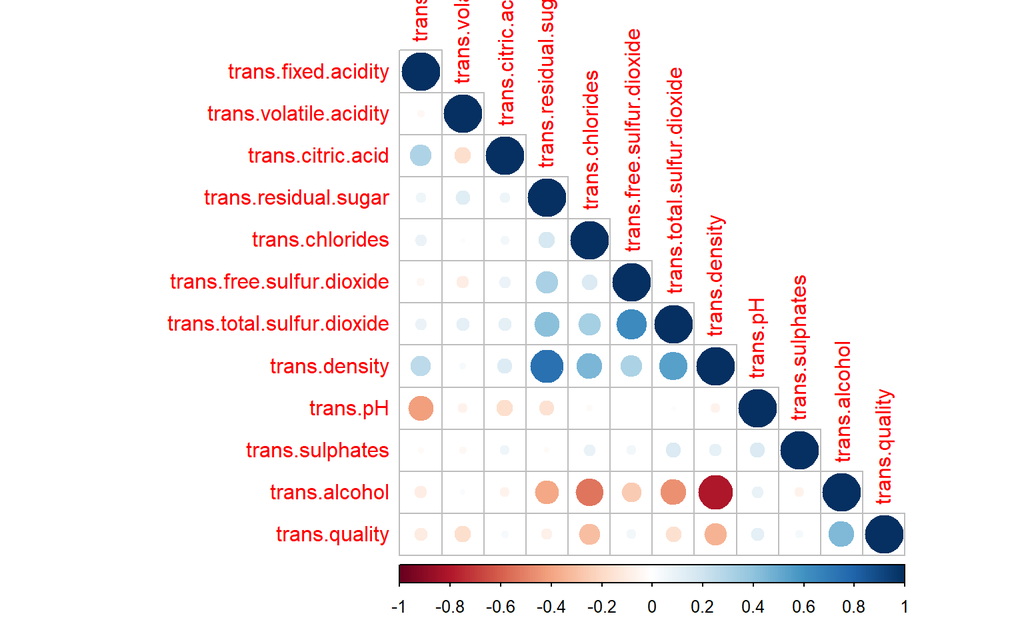

```r
corrplot(cor(new_white), type = "lower")
```

```r
vif(linear_4)
```

```
##     trans.volatile.acidity       trans.residual.sugar
##                   1.109472                   1.348887
##            trans.chlorides  trans.free.sulfur.dioxide
##                   1.424964                   1.836333
## trans.total.sulfur.dioxide                   trans.pH
##                   2.305832                   1.058009
##            trans.sulphates              trans.alcohol
##                   1.074973                   1.736160
```

## ANOVA

Analysis of variance (ANOVA) is a collection of statistical models and their associated estimation procedures used to analyze the differences among group means in a sample. ANOVA provides a statistical test of whether the population means of several groups are equal, and therefore generalizes the t-test to more than two groups. It is useful for comparing (testing) three or more group means for statistical significance.

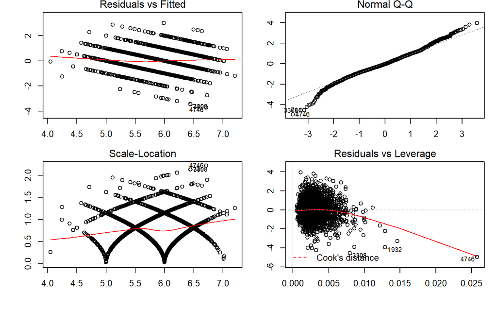

```r
par(mfrow=c(2,2), oma = c(1,1,0,0) + 0.1, mar = c(3,3,1,1) + 0.1)

plot(linear_4)
```

## F - Test

Null Hypothesis - Ho : B1 = B2 = B3 = B4 = 0 Alternate Hypothesis - Ho : B1 or B2 ….B11 != 0 (Bj where j ranges from 1 to 11)

F- Statistic - p value <= 2.2e -16

We can see that p value is less than 0.05. Thus we can reject the null hypothesis and accept the alternate hypothesis. Thus,we can say that the model is significant.

## Stepwise

```r
steplinear <- step(linear_0)
```

```
## Start:  AIC=-1705.85
## trans.quality ~ trans.fixed.acidity + trans.volatile.acidity +
##     trans.citric.acid + trans.residual.sugar + trans.chlorides +
##     trans.free.sulfur.dioxide + trans.total.sulfur.dioxide +
##     trans.density + trans.pH + trans.sulphates + trans.alcohol
##
##                              Df Sum of Sq    RSS     AIC
## <none>                                    1685.4 -1705.8
## - trans.total.sulfur.dioxide  1     3.469 1688.9 -1701.7
## - trans.fixed.acidity         1     5.226 1690.6 -1698.6
## - trans.chlorides             1     7.090 1692.5 -1695.3
## - trans.citric.acid           1     8.571 1694.0 -1692.6
## - trans.alcohol               1    11.030 1696.4 -1688.3
## - trans.sulphates             1    15.206 1700.6 -1680.9
## - trans.free.sulfur.dioxide   1    24.957 1710.3 -1663.8
## - trans.pH                    1    28.788 1714.2 -1657.0
## - trans.density               1    39.107 1724.5 -1639.0
## - trans.residual.sugar        1    64.932 1750.3 -1594.4
## - trans.volatile.acidity      1    67.124 1752.5 -1590.7
```

```r
summary(steplinear)
```

```
##
## Call:
## lm(formula = trans.quality ~ trans.fixed.acidity + trans.volatile.acidity +
##     trans.citric.acid + trans.residual.sugar + trans.chlorides +
##     trans.free.sulfur.dioxide + trans.total.sulfur.dioxide +
##     trans.density + trans.pH + trans.sulphates + trans.alcohol,
##     data = whitetrain)
##
## Residuals:
##     Min      1Q  Median      3Q     Max
## -3.7154 -0.4737 -0.0370  0.4768  3.0699
##
## Coefficients:
##                            Estimate Std. Error t value Pr(>|t|)
## (Intercept)                 5.86221    0.01377 425.612  < 2e-16 ***
## trans.fixed.acidity         0.06476    0.02128   3.044 0.002356 **
## trans.volatile.acidity     -0.16696    0.01530 -10.909  < 2e-16 ***
## trans.citric.acid           0.06819    0.01749   3.898 9.91e-05 ***
## trans.residual.sugar        0.35957    0.03351  10.729  < 2e-16 ***
## trans.chlorides            -0.06810    0.01921  -3.545 0.000398 ***
## trans.free.sulfur.dioxide   0.12545    0.01886   6.652 3.43e-11 ***
## trans.total.sulfur.dioxide -0.05308    0.02141  -2.480 0.013199 *
## trans.density              -0.47660    0.05724  -8.327  < 2e-16 ***
## trans.pH                    0.13383    0.01873   7.144 1.13e-12 ***
## trans.sulphates             0.07597    0.01463   5.192 2.22e-07 ***
## trans.alcohol               0.15887    0.03593   4.422 1.01e-05 ***
## ---
## Signif. codes:  0 '***' 0.001 '**' 0.01 '*' 0.05 '.' 0.1 ' ' 1
##
## Residual standard error: 0.751 on 2988 degrees of freedom
## Multiple R-squared:  0.308,  Adjusted R-squared:  0.3055
## F-statistic: 120.9 on 11 and 2988 DF,  p-value: < 2.2e-16
```

### ANOVA

Analysis of variance (ANOVA) is a collection of statistical models and their associated estimation procedures used to analyze the differences among group means in a sample. ANOVA provides a statistical test of whether the population means of several groups are equal, and therefore generalizes the t-test to more than two groups. It is useful for comparing (testing) three or more group means for statistical significance.

```r
anova(linear_4,steplinear)
```

```
## Analysis of Variance Table
##
## Model 1: trans.quality ~ (trans.fixed.acidity + trans.volatile.acidity +
##     trans.citric.acid + trans.residual.sugar + trans.chlorides +
##     trans.free.sulfur.dioxide + trans.total.sulfur.dioxide +
##     trans.density + trans.pH + trans.sulphates + trans.alcohol) -
##     trans.density - trans.fixed.acidity - trans.citric.acid
## Model 2: trans.quality ~ trans.fixed.acidity + trans.volatile.acidity +
##     trans.citric.acid + trans.residual.sugar + trans.chlorides +
##     trans.free.sulfur.dioxide + trans.total.sulfur.dioxide +
##     trans.density + trans.pH + trans.sulphates + trans.alcohol
##   Res.Df    RSS Df Sum of Sq      F    Pr(>F)
## 1   2991 1733.2
## 2   2988 1685.4  3    47.827 28.264 < 2.2e-16 ***
## ---
## Signif. codes:  0 '***' 0.001 '**' 0.01 '*' 0.05 '.' 0.1 ' ' 1
```

Used the stepwise model because it has lower RSS and ANOVA tells that it’s significant.

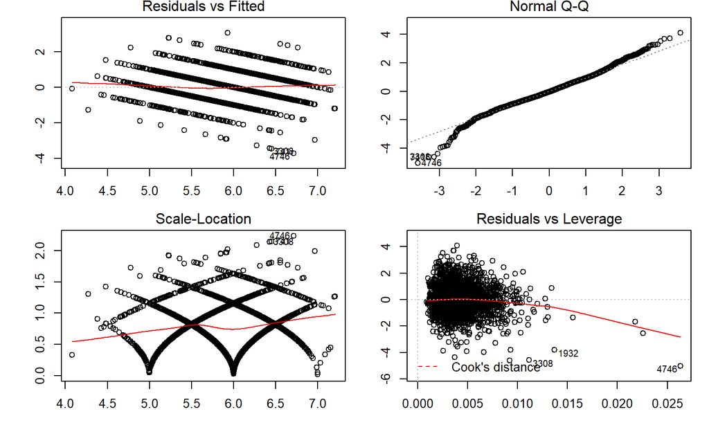

```r
par(mfrow=c(2,2), oma = c(1,1,0,0) + 0.1, mar = c(3,3,1,1) + 0.1)


plot(steplinear)
```

**Residuals vs Fitted** plot shows if residuals have non-linear patterns.Residuals around a horizontal line without distinct patterns, that is a good indication we don’t have non-linear relationships.

**Normal QQ** plot shows residuals fitting the line. Hence, can call it norlly distibuted residuals.

**Scale-Location** plot shows if residuals are spread equally along the ranges of predictors. This is how you can check the assumption of equal variance (homoscedasticity). It’s good if you see a horizontal line with equally (randomly) spread points.

**Residuals vs Leverage** plot has a typical look when there is some influential case. You can barely see Cook’s distance lines (a red dashed line) because all cases are well inside of the Cook’s distance.

## Predicting - Trained Set

Predict is a generic function for predictions from the results of various model fitting functions. The function invokes particular methods which depend on the class of the first argument.

```r
distPred <- predict(steplinear, whitetrain)
head(distPred)
```

```
##     1426     1180     2658      259     2246     2323
## 5.880671 5.626071 6.517168 6.331008 5.915127 5.247180
```

## Converting the Number to a Whole Number

We use the ceiling operation for rounding the numeric values towards near integer values.

```r
distPred1 <- ceiling(distPred)
head(distPred1)
```

```
## 1426 1180 2658  259 2246 2323
##    6    6    7    7    6    6
```

## Training Data Confusion Matrix

Table function performs categorical tabulation of data with the variable and its frequency. table() function is also helpful in creating Frequency tables with condition and cross tabulations.

```r
trn_tab <- table(predicted = distPred1, actual = whitetrain$trans.quality)
trn_tab
```

```
##          actual
## predicted   3   4   5   6   7   8   9
##         5   2  20  71  20   1   0   0
##         6   7  85 718 700 114  16   1
##         7   4   8 106 601 421  92   3
##         8   0   0   0   2   5   3   0
```

## Accuracy for the Linear Model

We check the accuracy of the linear model.

```r
sum(diag(trn_tab))/length(whitetest$trans.quality)
```

```
## [1] 0.26
```

Accuracy Prediction over train set Linear Model is 26%.

## Testing or Validating the Model

```r
distPred <- predict(steplinear, whitetest)
head(distPred)
```

```
##        1        4       13       25       28       30
## 4.900123 5.784360 6.037997 5.133616 5.952417 6.431214
```

```r
distPred1 <- ceiling(distPred)
head(distPred1)
```

```
##  1  4 13 25 28 30
##  5  6  7  6  6  7
```

```r
tst_tab <- table(predicted = distPred1, actual = whitetest$trans.quality)
tst_tab
```

```
##          actual
## predicted   3   4   5   6   7   8
##         5   1   6  17   6   1   0
##         6   1  20 166 204  20   1
##         7   1   2  25 162 103  12
##         8   0   0   0   0   2   0
```

## Accuracy - Test Data

Checking the accuracy of the test data.

```r
sum(diag(tst_tab))/length(whitetest$trans.quality)
```

```
## [1] 0.06133333
```

Accuracy Prediction over test set Linear Model is 6.13%.

# Ordinal Logistic Regression Model

## Assumptions for Logistic Regression

First, binary logistic regression requires the dependent variable to be **binary and ordinal** logistic regression requires the dependent variable to be ordinal.

Second, logistic regression requires the observations to be independent of each other. In other words, the observations should not come from repeated measurements or matched data.

Third, logistic regression requires there to be **little or no multicollinearity** among the independent variables. This means that the independent variables should not be too highly correlated with each other.

Fourth, logistic regression assumes **linearity of independent variables and log odds**. although this analysis does not require the dependent and independent variables to be related linearly, it requires that the independent variables are linearly related to the log odds. *(Did Not check for this! To improve model. We can try this in future.)*

Finally, logistic regression typically requires a large sample size.

Ordinal logistic regression can be used to model a ordered factor response.

We use as.factor() to covert the variables into factors, that is, categorical variables.

```r
#using the orignal and making changes specifically required for Logistic Regession.

white$quality2 <- as.factor(white$quality)
```

## Train - Test Set

```r
set.seed(3000)
spl = sample.split(white$quality2, SplitRatio = 0.7)

whitetrain = subset(white, spl==TRUE)
whitetest = subset(white, spl==FALSE)

head(whitetrain)
```

```
##    fixed.acidity volatile.acidity citric.acid residual.sugar chlorides
## 2            6.3             0.30        0.34           1.60     0.049
## 7            6.2             0.32        0.16           7.00     0.045
## 10           8.1             0.22        0.43           1.50     0.044
## 11           8.1             0.27        0.41           1.45     0.033
## 12           8.6             0.23        0.40           4.20     0.035
## 13           7.9             0.18        0.37           1.20     0.040
##    free.sulfur.dioxide total.sulfur.dioxide density   pH sulphates alcohol
## 2                   14                  132  0.9940 3.30      0.49     9.5
## 7                   30                  136  0.9949 3.18      0.47     9.6
## 10                  28                  129  0.9938 3.22      0.45    11.0
## 11                  11                   63  0.9908 2.99      0.56    12.0
## 12                  17                  109  0.9947 3.14      0.53     9.7
## 13                  16                   75  0.9920 3.18      0.63    10.8
##    quality quality2
## 2        6        6
## 7        6        6
## 10       6        6
## 11       5        5
## 12       5        5
## 13       5        5
```

## Fitting Model

polr() is the fuction used to fit the ordinal logistic regression model.

```r
require(MASS)
require(reshape2)
# Hess=TRUE to let the model output show the observed information matrix from optimization which is used to get standard errors.
o_lrm <- polr(quality2 ~ . - quality, data = whitetrain, Hess=TRUE)
```

```r
# should not use vif to check for multicollinarilty in case of categorical veriable.

vif(o_lrm)
```

```
##        fixed.acidity     volatile.acidity          citric.acid
##         9.437704e+08         3.828385e+08         6.424758e+05
##       residual.sugar            chlorides  free.sulfur.dioxide
##         1.845434e+12         1.457669e+00         6.425308e+00
## total.sulfur.dioxide              density                   pH
##         2.228460e+16         4.943074e+10         1.096931e+10
##            sulphates              alcohol
##         1.373230e+08         2.243821e+16
```

```r
summary(o_lrm)
```

```
## Call:
## polr(formula = quality2 ~ . - quality, data = whitetrain, Hess = TRUE)
##
## Coefficients:
##                           Value Std. Error  t value
## fixed.acidity           0.19109   0.049513    3.859
## volatile.acidity       -4.16006   0.396986  -10.479
## citric.acid             0.47473   0.315331    1.506
## residual.sugar          0.18950   0.009254   20.477
## chlorides              -1.02123   1.618406   -0.631
## free.sulfur.dioxide     0.01804   0.002996    6.022
## total.sulfur.dioxide   -0.00179   0.001256   -1.425
## density              -405.55303   0.611027 -663.724
## pH                      2.37597   0.279420    8.503
## sulphates               1.83492   0.325575    5.636
## alcohol                 0.51080   0.042104   12.132
##
## Intercepts:
##     Value     Std. Error t value
## 3|4 -393.5020    0.6212  -633.4946
## 4|5 -391.1957    0.6196  -631.3735
## 5|6 -388.2891    0.6262  -620.0709
## 6|7 -385.6073    0.6410  -601.5335
## 7|8 -383.3112    0.6550  -585.2349
## 8|9 -380.0386    0.8192  -463.9258
##
## Residual Deviance: 6145.137
## AIC: 6179.137
```

Smaller the AIC better is the model. So let’s try step wise logistic regression.

## Stepwise

```r
o_lr = step(o_lrm)
```

```
## Start:  AIC=6179.14
## quality2 ~ (fixed.acidity + volatile.acidity + citric.acid +
##     residual.sugar + chlorides + free.sulfur.dioxide + total.sulfur.dioxide +
##     density + pH + sulphates + alcohol + quality) - quality
##
##                        Df    AIC
## - chlorides             1 6177.5
## - total.sulfur.dioxide  1 6179.0
## <none>                    6179.1
## - citric.acid           1 6179.4
## - fixed.acidity         1 6183.7
## - alcohol               1 6203.4
## - sulphates             1 6206.0
## - density               1 6207.4
## - free.sulfur.dioxide   1 6213.1
## - pH                    1 6217.6
## - residual.sugar        1 6222.9
## - volatile.acidity      1 6287.0
##
## Step:  AIC=6177.52
## quality2 ~ fixed.acidity + volatile.acidity + citric.acid + residual.sugar +
##     free.sulfur.dioxide + total.sulfur.dioxide + density + pH +
##     sulphates + alcohol
##
##                        Df    AIC
## - total.sulfur.dioxide  1 6177.4
## <none>                    6177.5
## - citric.acid           1 6177.6
## - fixed.acidity         1 6183.0
## - alcohol               1 6201.6
## - sulphates             1 6204.9
## - density               1 6208.0
## - free.sulfur.dioxide   1 6211.1
## - pH                    1 6218.7
## - residual.sugar        1 6225.4
## - volatile.acidity      1 6288.9
##
## Step:  AIC=6177.36
## quality2 ~ fixed.acidity + volatile.acidity + citric.acid + residual.sugar +
##     free.sulfur.dioxide + density + pH + sulphates + alcohol
```

[output cut: 12 more lines]

```
##
## Step:  AIC=6177.31
## quality2 ~ fixed.acidity + volatile.acidity + residual.sugar +
##     free.sulfur.dioxide + density + pH + sulphates + alcohol
##
##                       Df    AIC
## <none>                   6177.3
## - fixed.acidity        1 6184.9
## - alcohol              1 6201.8
## - density              1 6211.8
## - sulphates            1 6212.1
## - pH                   1 6218.1
## - free.sulfur.dioxide  1 6225.9
## - residual.sugar       1 6228.4
## - volatile.acidity     1 6316.1
```

We see some of the variables got eliminated.

fixed.acidity, alcohol, density, sulphates, pH, free.sulfur.dioxide, residual.sugar, volatile.acidity are the variables being considered.

```r
head(fitted(o_lr))
```

```
##              3           4         5         6          7           8
## 2  0.012733201 0.102476569 0.5891421 0.2675954 0.02514971 0.002792462
## 7  0.007370319 0.062364804 0.5085991 0.3739248 0.04270917 0.004839804
## 10 0.002796939 0.024740172 0.3137434 0.5415504 0.10395809 0.012702967
## 11 0.001083919 0.009752403 0.1561342 0.5775992 0.22198247 0.032135733
## 12 0.005402251 0.046583924 0.4488420 0.4350332 0.05727276 0.006603401
## 13 0.001270388 0.011408834 0.1775801 0.5833461 0.19772064 0.027554412
##               9
## 2  0.0001105250
## 7  0.0001919682
## 10 0.0005080325
## 11 0.0013121200
## 12 0.0002624039
## 13 0.0011195326
```

## Training Set Accuracy

predicting -

```r
p <- predict(o_lr, type = "class")
head(p)
```

```
## [1] 5 5 6 6 5 6
## Levels: 3 4 5 6 7 8 9
```

```r
cm1 = as.matrix(table(Actual = whitetrain$quality2, Predicted = p))
cm1
```

```
##       Predicted
## Actual   3   4   5   6   7   8   9
##      3   0   1   5   7   0   1   0
##      4   0   4  64  38   1   0   0
##      5   0   0 425 393   4   0   0
##      6   1   0 239 936  76   0   0
##      7   0   0  19 355 107   1   0
##      8   0   0   2  59  31   0   0
##      9   0   0   0   1   3   0   0
```

```r
sum(diag(cm1))/length(whitetrain$quality2)
```

```
## [1] 0.530833
```

Training Set Accuracy is 53.08%

## Test Set Accuracy

Accuray for the test set.

```r
tst_pred <- predict(o_lr, newdata = whitetest, type = "class")
```

## Confusion Matrix Test

```r
cm2 <- table(predicted = tst_pred, actual = whitetest$quality2)
cm2
```

```
##          actual
## predicted   3   4   5   6   7   8   9
##         3   0   0   0   0   0   0   0
##         4   0   0   0   0   0   0   0
##         5   2  32 177  93   6   1   0
##         6   3  14 171 410 156  26   0
##         7   1   0   5  33  45  12   1
##         8   0   0   0   0   0   0   0
##         9   0   0   0   0   0   0   0
```

## Test Set Accuracy

```r
sum(diag(cm2))/length(whitetrain$quality2)
```

```
## [1] 0.227912
```

Test Set Accuracy - 22.8 %

# Binomial Logistic Regression Model

The variable to be predicted is binary and hence we use binomial logistic regression.

```r
white$category[white$quality <= 5] <- 0
white$category[white$quality > 5] <- 1

white$category <- as.factor(white$category)
```

```r
head(white)
```

```
##    fixed.acidity volatile.acidity citric.acid residual.sugar chlorides
## 1            7.0             0.27        0.36           20.7     0.045
## 2            6.3             0.30        0.34            1.6     0.049
## 3            8.1             0.28        0.40            6.9     0.050
## 4            7.2             0.23        0.32            8.5     0.058
## 7            6.2             0.32        0.16            7.0     0.045
## 10           8.1             0.22        0.43            1.5     0.044
##    free.sulfur.dioxide total.sulfur.dioxide density   pH sulphates alcohol
## 1                   45                  170  1.0010 3.00      0.45     8.8
## 2                   14                  132  0.9940 3.30      0.49     9.5
## 3                   30                   97  0.9951 3.26      0.44    10.1
## 4                   47                  186  0.9956 3.19      0.40     9.9
## 7                   30                  136  0.9949 3.18      0.47     9.6
## 10                  28                  129  0.9938 3.22      0.45    11.0
##    quality quality2 category
## 1        6        6        1
## 2        6        6        1
## 3        6        6        1
## 4        6        6        1
## 7        6        6        1
## 10       6        6        1
```

## Train Test Split

```r
set.seed(3000)

spl = sample.split(white$category, SplitRatio = 0.7)

whitetrain = subset(white, spl==TRUE)
whitetest = subset(white, spl==FALSE)


head(whitetrain)
```

```
##    fixed.acidity volatile.acidity citric.acid residual.sugar chlorides
## 2            6.3             0.30        0.34           1.60     0.049
## 7            6.2             0.32        0.16           7.00     0.045
## 10           8.1             0.22        0.43           1.50     0.044
## 11           8.1             0.27        0.41           1.45     0.033
## 13           7.9             0.18        0.37           1.20     0.040
## 15           8.3             0.42        0.62          19.25     0.040
##    free.sulfur.dioxide total.sulfur.dioxide density   pH sulphates alcohol
## 2                   14                  132  0.9940 3.30      0.49     9.5
## 7                   30                  136  0.9949 3.18      0.47     9.6
## 10                  28                  129  0.9938 3.22      0.45    11.0
## 11                  11                   63  0.9908 2.99      0.56    12.0
## 13                  16                   75  0.9920 3.18      0.63    10.8
## 15                  41                  172  1.0002 2.98      0.67     9.7
##    quality quality2 category
## 2        6        6        1
## 7        6        6        1
## 10       6        6        1
## 11       5        5        0
## 13       5        5        0
## 15       5        5        0
```

glm()= Generalized linear model

```r
model_glm <- glm(category ~ . - quality - quality2, data = whitetrain, family=binomial(link = "logit"))
#backwards = step(fullmod,trace=0) would suppress step by step output.
```

## Stepwise

```r
model_gl <- step(model_glm)
```

```
## Start:  AIC=2821.85
## category ~ (fixed.acidity + volatile.acidity + citric.acid +
##     residual.sugar + chlorides + free.sulfur.dioxide + total.sulfur.dioxide +
##     density + pH + sulphates + alcohol + quality + quality2) -
##     quality - quality2
##
##                        Df Deviance    AIC
## - total.sulfur.dioxide  1   2797.9 2819.9
## - chlorides             1   2797.9 2819.9
## - fixed.acidity         1   2798.0 2820.0
## <none>                      2797.8 2821.8
## - citric.acid           1   2800.2 2822.2
## - free.sulfur.dioxide   1   2806.9 2828.9
## - pH                    1   2809.7 2831.7
## - density               1   2811.5 2833.5
## - sulphates             1   2817.4 2839.4
## - residual.sugar        1   2823.2 2845.2
## - alcohol               1   2826.3 2848.3
## - volatile.acidity      1   2916.6 2938.6
##
## Step:  AIC=2819.87
## category ~ fixed.acidity + volatile.acidity + citric.acid + residual.sugar +
##     chlorides + free.sulfur.dioxide + density + pH + sulphates +
##     alcohol
##
##                       Df Deviance    AIC
## - chlorides            1   2798.0 2818.0
## - fixed.acidity        1   2798.0 2818.0
## <none>                     2797.9 2819.9
## - citric.acid          1   2800.2 2820.2
## - pH                   1   2809.7 2829.7
## - density              1   2811.8 2831.8
## - free.sulfur.dioxide  1   2813.1 2833.1
## - sulphates            1   2817.8 2837.8
## - residual.sugar       1   2823.4 2843.4
## - alcohol              1   2826.6 2846.6
## - volatile.acidity     1   2920.6 2940.6
##
## Step:  AIC=2817.97
## category ~ fixed.acidity + volatile.acidity + citric.acid + residual.sugar +
```

[output cut: 13 more lines]

```
##
## Step:  AIC=2816.17
## category ~ volatile.acidity + citric.acid + residual.sugar +
##     free.sulfur.dioxide + density + pH + sulphates + alcohol
##
##                       Df Deviance    AIC
## <none>                     2798.2 2816.2
## - citric.acid          1   2800.6 2816.6
## - free.sulfur.dioxide  1   2813.1 2829.1
## - pH                   1   2817.6 2833.6
## - sulphates            1   2818.2 2834.2
## - density              1   2824.1 2840.1
## - residual.sugar       1   2841.8 2857.8
## - alcohol              1   2863.4 2879.4
## - volatile.acidity     1   2927.8 2943.8
```

```r
#model_gl = step(model_glm,trace=0) would suppress step by step output.
```

## Prediction - Train

The default is on the scale of the linear predictors; the alternative “response” is on the scale of the response variable. Thus for a default binomial model the default predictions are of log-odds (probabilities on logit scale) and type = “response” gives the predicted probabilities

```r
head(fitted(model_gl))
```

```
##         2         7        10        11        13        15
## 0.3085439 0.3942105 0.6825519 0.8508986 0.8124451 0.4915685
```

```r
head(predict(model_gl))
```

```
##           2           7          10          11          13          15
## -0.80693550 -0.42964756  0.76552441  1.74166660  1.46597646 -0.03372931
```

```r
head(predict(model_gl, type = "response"))
```

```
##         2         7        10        11        13        15
## 0.3085439 0.3942105 0.6825519 0.8508986 0.8124451 0.4915685
```

### Catagorizing Set

```r
trn_pred <- ifelse(predict(model_gl, type = "response") > 0.5,"Good Wine", "Bad Wine")
head(trn_pred)
```

```
##           2           7          10          11          13          15
##  "Bad Wine"  "Bad Wine" "Good Wine" "Good Wine" "Good Wine"  "Bad Wine"
```

## Confusion Matrix - Training Set

Obtaining confusion matrix of the training data.

```r
trn_tab <- table(predicted = trn_pred, actual = whitetrain$category)
trn_tab
```

```
##            actual
## predicted      0    1
##   Bad Wine   504  254
##   Good Wine  440 1575
```

## Training Set Accuracy

Checking accuracy of the training set.

```r
sum(diag(trn_tab))/length(whitetrain$category)
```

```
## [1] 0.7497295
```

We can see that Binomial Logistic Regressio gives an training set accuracy of 74.97295%.

## Confusion Matrix - Test Set

Confusion matrix for the test data.

```r
# Making predictions on the test set.
tst_pred <- ifelse(predict(model_gl, newdata = whitetest, type = "response") > 0.5, "Good Wine", "Bad Wine")
tst_tab <- table(predicted = tst_pred, actual = whitetest$category)
tst_tab
```

```
##            actual
## predicted     0   1
##   Bad Wine  212 110
##   Good Wine 192 674
```

## Test Set Accuracy

Checking accuracy for the test data.

```r
sum(diag(tst_tab))/length(whitetest$category)
```

```
## [1] 0.7457912
```

We can see that Binomial Logistic Regression gives an test set accuracy of 74.58%.

# Conclusion

**Please, use binomial logistic regression to predict the quality of wine.**

Shradhit Subudhi

December 3, 2018